# Проект для «Викишоп»

## Введение

Интернет-магазин «Викишоп» запускает новый сервис. Теперь пользователи могут редактировать и дополнять описания товаров, как в вики-сообществах. То есть клиенты предлагают свои правки и комментируют изменения других. Магазину нужен инструмент, который будет искать токсичные комментарии и отправлять их на модерацию.

Обучите модель классифицировать комментарии на позитивные и негативные. В вашем распоряжении набор данных с разметкой о токсичности правок.

Постройте модель со значением метрики качества *F1* не меньше 0.75.

**Описание данных**

Данные находятся в файле `toxic_comments.csv`. Столбец *text* в нём содержит текст комментария, а *toxic* — целевой признак.

## Библиотеки и настройки

### Библиотеки

```python
# ! pip install -U pip setuptools wheel
! pip install -q spacy
```

```python
!pip install -q https://github.com/explosion/spacy-models/releases/download/en_core_web_sm-3.0.0/en_core_web_sm-3.0.0.tar.gz
```

```python
!pip install -q optuna
```

```python
import pandas as pd


import numpy as np

# для графиков
import matplotlib.pyplot as plt
import seaborn as sns

#для загрузки данных и с сервера и локально
import os
# для скрытия ошибок
import warnings
from IPython.display import display
# для условно рандомных состояний
from numpy.random import RandomState
# регулярные выражения
import re
#Лемматизатор
import spacy
# модель для лемматизации английского языка
import en_core_web_sm

# разбиение на выборки
from sklearn.model_selection import train_test_split

# расчитаем TF-IDF
from sklearn.feature_extraction.text import TfidfVectorizer
from nltk.corpus import stopwords
import nltk

# Логистическая регрессия
from sklearn.linear_model import LogisticRegression
# перемешивание данных
from sklearn.utils import shuffle

# F1 метрика
from sklearn.metrics import f1_score

import lightgbm as lgb
```

### Настройки

```python
# для скрытия ошибок
warnings.filterwarnings("ignore")

# для увеличения окна вывода
pd.options.display.max_rows = 300
# максимальная вместимость ячейки для отображения
pd.set_option('display.max_colwidth', None)
# четыре знака после запятой
pd.set_option('display.float_format', '{:.4f}'.format)

# для задания размера графиков по умолчанию
plt.rcParams["figure.figsize"] = (7, 5)

# для псевдорандомных значений
np.random.seed(seed=321)
np.random.RandomState(seed=321)
rs=321

# загрузим английские стоп слова
nltk.download('stopwords')
stop_words = set(stopwords.words('english'))
```

## Подготовка

### Загрузка данных

Загрузим данные сразу придим им нужный формат.

```python
#путь с сервероной версии
pth1 = '/datasets/toxic_comments.csv'
# моя локальная версия
pth2 = 'toxic_comments.csv'

# загрузка данных
if os.path.exists(pth1):
    df = pd.read_csv(pth1, index_col='Unnamed: 0'
#                      , dtype={'toxic': int, 'text': 'U'}
                    )
elif os.path.exists(pth2):
    df = pd.read_csv(pth2, index_col='Unnamed: 0'
#                      , dtype={'toxic': int, 'text': 'U'}
                    )
else:
    display('Проверьте пути к файлам с данными!')

df.info()
df.head()
```

```
<class 'pandas.core.frame.DataFrame'>
Int64Index: 159292 entries, 0 to 159450
Data columns (total 2 columns):
 #   Column  Non-Null Count   Dtype
---  ------  --------------   -----
 0   text    159292 non-null  object
 1   toxic   159292 non-null  int64
dtypes: int64(1), object(1)
memory usage: 3.6+ MB
```

|  | text | toxic |
| --- | --- | --- |
| 0 | Explanation\nWhy the edits made under my username Hardcore Metallica Fan were reverted? They weren't vandalisms, just closure on some GAs after I voted at New York Dolls FAC. And please don't remove t… | 0 |
| 1 | D'aww! He matches this background colour I'm seemingly stuck with. Thanks. (talk) 21:51, January 11, 2016 (UTC) | 0 |
| 2 | Hey man, I'm really not trying to edit war. It's just that this guy is constantly removing relevant information and talking to me through edits instead of my talk page. He seems to care more about the… | 0 |
| 3 | "\nMore\nI can't make any real suggestions on improvement - I wondered if the section statistics should be later on, or a subsection of ""types of accidents"" -I think the references may need tidying … | 0 |
| 4 | You, sir, are my hero. Any chance you remember what page that's on? | 0 |

```python
%%time
# Код ревьюера.
import chardet
# define a function to determine the encoding format of a string
def get_encoding(s):
    # use chardet to detect the encoding format of the string
    result = chardet.detect(s[0].encode())
    return result['encoding']

# iterate over each string in the series and print the detected encoding format
formats = df['text'].apply(get_encoding)

formats.unique()
```

```
CPU times: user 1.22 s, sys: 7.03 ms, total: 1.23 s
Wall time: 1.24 s
```

```
array(['ascii', 'Windows-1252', 'utf-8', 'ISO-8859-1', 'UTF-8-SIG',
       'TIS-620'], dtype=object)
```

```python
del formats
```

**Вывод**: Данные загружены корректно.

### Анализ данных

#### Дисбаланс класса на всех данных

```python
display(df['toxic'].unique())
df['toxic'].mean()
```

```
array([0, 1])
```

```
0.10161213369158527
```

**Вывод**: Мы видим сильный дисбаланс класса: отрицательный класс к положительному как 9 к 1.

#### Максимальная длина строки

Найдем максимальную длину отзыва.

```python
max_len = len(max(df['text'], key=len))
max_len
```

```
5000
```

Вот это да, у кого-то нервы не выдержали...

Но нам нужны реальные данные, чтобы наши аппаратные мощьности смогли это обработать.

Посмотрим статистику и график по длинам отзывов.

```python
df['len']= df['text'].apply(lambda x: len(x))
df['len'].describe()
```

```
count   159292.0000
mean       393.6913
std        590.1118
min          5.0000
25%         95.0000
50%        205.0000
75%        435.0000
max       5000.0000
Name: len, dtype: float64
```

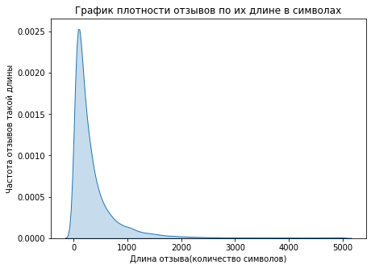

```python
# df['len'].hist(bins=50)
sns.kdeplot(data = df['len'], shade=True)
plt.title('График плотности отзывов по их длине в символах')
plt.xlabel('Длина отзыва(количество символов)')
plt.ylabel('Частота отзывов такой длины')
plt.show()
```

```python
# max_len = 1000
# display('Если мы оставим отзывы с длиной до {}, то мы сохраним {:.2%} всех отзывов.'.format(max_len,
#     df[df['len'] <=max_len]['len'].count() / df['len'].count()))
```

~**Вывод**: Примем волевое решение и уберём из наших данных все отзывы длиною более выбранной нами максимальной длины символов. Это нужно для экономии аппаратных ресурсов.

**Вывод**: Много слов. Но идем дельше.

Далее информация о длине отзыва на не понадобится. Удалим её.

```python
df.drop(columns='len', inplace=True)
df.columns
```

```
Index(['text', 'toxic'], dtype='object')
```

```python
# # df_features = df.sample(n=32000, replace=False, weights=None, random_state=rs)
df_features=df
# df_features.info()
```

### Обработка

Результаты обработок мы будем сохранять в дополнительный столбец `lemm_text`.

#### Очистка от лишних символов.

Напишем фунцию для очистки текста и приведению слов к нижнему регистру.

```python
def clear_text(text):
    return " ".join(re.sub(r'[^A-Za-z]', ' ', text).split()).lower()

display(df.loc[1, 'text'])
display(clear_text(df.loc[1, 'text']))
```

```
"D'aww! He matches this background colour I'm seemingly stuck with. Thanks.  (talk) 21:51, January 11, 2016 (UTC)"
```

```
'd aww he matches this background colour i m seemingly stuck with thanks talk january utc'
```

#### Лемматизация

Напишем функцию для лемматизации текста.

```python
# nlp = spacy.load('en_core_web_sm')
nlp = spacy.load('en_core_web_sm', disable=['parser', 'ner'])

def lemmatize(text):
    global nlp
    doc = nlp(text)
    return " ".join([token.lemma_ for token in doc])
```

Применим функции очистки и лемматизации текста.

```python
df_features['lemm_text'] = df_features['text'].apply(clear_text).apply(lemmatize)
df_features.head()
```

|  | text | toxic | lemm_text |
| --- | --- | --- | --- |
| 0 | Explanation\nWhy the edits made under my username Hardcore Metallica Fan were reverted? They weren't vandalisms, just closure on some GAs after I voted at New York Dolls FAC. And please don't remove t… | 0 | explanation why the edit make under my username hardcore metallica fan be revert they weren t vandalism just closure on some gas after I vote at new york doll fac and please don t remove the template … |
| 1 | D'aww! He matches this background colour I'm seemingly stuck with. Thanks. (talk) 21:51, January 11, 2016 (UTC) | 0 | d aww he match this background colour I m seemingly stuck with thank talk january utc |
| 2 | Hey man, I'm really not trying to edit war. It's just that this guy is constantly removing relevant information and talking to me through edits instead of my talk page. He seems to care more about the… | 0 | hey man I m really not try to edit war it s just that this guy be constantly remove relevant information and talk to I through edit instead of my talk page he seem to care more about the formatting th… |
| 3 | "\nMore\nI can't make any real suggestions on improvement - I wondered if the section statistics should be later on, or a subsection of ""types of accidents"" -I think the references may need tidying … | 0 | more I can t make any real suggestion on improvement I wonder if the section statistic should be later on or a subsection of type of accident I think the reference may need tidy so that they be all in… |
| 4 | You, sir, are my hero. Any chance you remember what page that's on? | 0 | you sir be my hero any chance you remember what page that s on |

Запишем в файл результат лемматизации.

```python
# записываем разультаты в файл
df_features.to_csv('lemm_text_file.csv', index=False)
```

```python
# берем обработанные данные из файла - экономи 2 часа жизни
df_features = pd.read_csv('lemm_text_file.csv')
df_features.head()
```

|  | text | toxic | lemm_text |
| --- | --- | --- | --- |
| 0 | Explanation\nWhy the edits made under my username Hardcore Metallica Fan were reverted? They weren't vandalisms, just closure on some GAs after I voted at New York Dolls FAC. And please don't remove t… | 0 | explanation why the edit make under my username hardcore metallica fan be revert they weren t vandalism just closure on some gas after I vote at new york doll fac and please don t remove the template … |
| 1 | D'aww! He matches this background colour I'm seemingly stuck with. Thanks. (talk) 21:51, January 11, 2016 (UTC) | 0 | d aww he match this background colour I m seemingly stuck with thank talk january utc |
| 2 | Hey man, I'm really not trying to edit war. It's just that this guy is constantly removing relevant information and talking to me through edits instead of my talk page. He seems to care more about the… | 0 | hey man I m really not try to edit war it s just that this guy be constantly remove relevant information and talk to I through edit instead of my talk page he seem to care more about the formatting th… |
| 3 | "\nMore\nI can't make any real suggestions on improvement - I wondered if the section statistics should be later on, or a subsection of ""types of accidents"" -I think the references may need tidying … | 0 | more I can t make any real suggestion on improvement I wonder if the section statistic should be later on or a subsection of type of accident I think the reference may need tidy so that they be all in… |
| 4 | You, sir, are my hero. Any chance you remember what page that's on? | 0 | you sir be my hero any chance you remember what page that s on |

**Вывод**: Лемматизация и очистка от символово прошла успешно.

### Разбиение на выборки

Так как при расчетах TFIDF мы можем допустить косвенную утечку данных, то разделим данные на тренировочную(60%), валидационную(20%) и тестовую(20%) выборки до этих расчетов.

А перед этим выделим целевой и обучающий признаки.

```python
target = df_features['toxic']
features = df_features['lemm_text']
```

```python
type(target), type(features)
```

```
(pandas.core.series.Series, pandas.core.series.Series)
```

```python
features_train, features_test, target_train, target_test = train_test_split(features, target
                                                                           , test_size=0.2
                                                                            , random_state=rs
                                                                            , stratify=target
                                                                           )
features_train.shape, features_test.shape, target_train.shape, target_test.shape
```

```
((127433,), (31859,), (127433,), (31859,))
```

```python
features_train, features_valid, target_train, target_valid = train_test_split(features_train, target_train
                                                                           , test_size=0.25
                                                                            , random_state=rs
                                                                            , stratify=target_train
                                                                           )
features_train.shape, features_valid.shape, target_train.shape, target_valid.shape
```

```
((95574,), (31859,), (95574,), (31859,))
```

```python
# проверим наш дисбаланс
target_test.mean(), target_valid.mean(), target_train.mean()
```

```
(0.10160394237107254, 0.10160394237107254, 0.10161759474334024)
```

**Вывод**: Разделения на целевой и обучающий признаки, а так же на тренировочную, валидационную/проверочную и тестовую прошли успешно. Дисбаланс класса сохранился везде.

#### Upsampling тренировочной выборки

Напишем функцию для борьбы с дисбалансом классов.

```python
# функция upsample для увеличения числа объектов для борьбы с дисбалансом классов
def upsample(X, y, repeat=10):
#     # перейдем в типы данных pd
#     X = pd.DataFrame(X, copy=True)
#     y = pd.Series(y, index=X.index, copy=True)
    # сделаем upsumpling
    features_zeros = X[y == 0]
    features_ones = X[y == 1]
    target_zeros = y[y == 0]
    target_ones = y[y == 1]


    features_upsampled = pd.concat([features_zeros] + [features_ones] * repeat)
    target_upsampled = pd.concat([target_zeros] + [target_ones] * repeat)


    features_upsampled, target_upsampled = shuffle(features_upsampled, target_upsampled, random_state=rs)

#     # вернемся в np
#     features_upsampled = features_upsampled.values
#     target_upsampled = target_upsampled.values

    return features_upsampled, target_upsampled
```

Подготовим сбалансированную тренировочную выборку.

```python
features_train_upsamled, target_train_upsampled = upsample(features_train, target_train, 9)
features_train_upsamled.shape, target_train_upsampled.shape
```

```
((173270,), (173270,))
```

**Вывод**: Мы подготовили сбалансированную тренировочную выборку по методу *upsampling*. И целевой тренировочный признак.

### TF-IDF: подготовка обучающий признаков

Пришло время от слов перейти к числам. Преобразуем наш обучающий признак в признаки, которые отражают как часто каждое слово входит и в сам объект и во все данные выборки. И, конечно, перед началом цифровизации уберем стоп-слова.

Важно, чтобы признаки у всех выборок были как тренировочной.

Напишем функцию, которая подготовит для нас обучающие признаки.

```python
def tf_idf_transform(train, valid, test):
    # приведем к нужному формату
    coprus_train = train.values #.astype('U')
    coprus_valid = valid.values #.astype('U')
    coprus_test = test.values #.astype('U')
    # создадим и обучим модель на тренировочной выборке для создания TFIDF матриц
    count_tf_idf = TfidfVectorizer(stop_words=stop_words).fit(coprus_train)
#     count_tf_idf.get_feature_names()
    # получим обучающие признаки
    result_train = count_tf_idf.transform(coprus_train)
    result_valid = count_tf_idf.transform(coprus_valid)
    result_test = count_tf_idf.transform(coprus_test)
    return result_train, result_valid, result_test
```

Применим её для тренировочной, валидационной и тестовой выборок.

```python
features_train_tf_idf, features_valid_tf_idf, features_test_tf_idf = tf_idf_transform(features_train
                                                                                     , features_valid
                                                                                     , features_test)
features_train_tf_idf, features_valid_tf_idf, features_test_tf_idf
```

```
(<95574x125135 sparse matrix of type '<class 'numpy.float64'>'
 	with 2595765 stored elements in Compressed Sparse Row format>,
 <31859x125135 sparse matrix of type '<class 'numpy.float64'>'
 	with 846779 stored elements in Compressed Sparse Row format>,
 <31859x125135 sparse matrix of type '<class 'numpy.float64'>'
 	with 847598 stored elements in Compressed Sparse Row format>)
```

**Вывод**: Был один признак огромной длины, а теперь много признаков, зато числовых. Это не сбалансированные данные. Подстрахуемся и продолжим готовить и сбалансированные данные.

#### TF-IDF: подготовка сбалансированных обучающий признаков

```python
features_train_upsamled_tf_idf, features_valid_upsampled_tf_idf, features_test_upsampled_tf_idf = tf_idf_transform(
    features_train_upsamled, features_valid, features_test)

features_train_upsamled_tf_idf, features_valid_upsampled_tf_idf, features_test_upsampled_tf_idf
```

```
(<173270x125135 sparse matrix of type '<class 'numpy.float64'>'
 	with 4039829 stored elements in Compressed Sparse Row format>,
 <31859x125135 sparse matrix of type '<class 'numpy.float64'>'
 	with 846779 stored elements in Compressed Sparse Row format>,
 <31859x125135 sparse matrix of type '<class 'numpy.float64'>'
 	with 847598 stored elements in Compressed Sparse Row format>)
```

**Вывод**: Мы получили сбалансированный набор данных для обучения моделей.

### Тип целевого признака

Приведем наши целевые признаки в разных выборках к сочетающему типу наших обучающиих признаков.

```python
target_train = target_train.values
target_valid = target_valid.values
target_test = target_test.values

target_train_upsampled = target_train_upsampled.values
```

```python
type(target_train), type(target_valid), type(target_test), type(target_train_upsampled)
```

```
(numpy.ndarray, numpy.ndarray, numpy.ndarray, numpy.ndarray)
```

**Вывод**: Целевой признак по типу готов.

## Обучение

Раз обучающие и целевые признаки готовы пора работать с моделями:

- мы будем обучать модели на тренировочных выборках,
- среди обученных моделей выберем ту, у которой F1-мера (гармоническое среднее точности и полноты) будет самое высокой и выше 0,75.
- победителя, проверим на тестовой выборке.

### Модели

#### Логистическая регрессия

Проверим наши показатели на настройках по умолчанию.

```python
model = LogisticRegression()
model.fit(features_train_tf_idf, target_train)
# F1 метрика на тренировочной выборке
f1_score(target_train, model.predict(features_train_tf_idf))
```

```
0.7600720094357191
```

```python
# F1 метрика на проверочной выборке
f1_score(target_valid, model.predict(features_valid_tf_idf))
```

```
0.7373548145372799
```

**Вывод**: Модель плохо обучилась и на проверочных показателях показала плохие показетели.

Но не будем забывать, что у нас большой дисбаланс классов. Проверим работу модели на сбалансированных данных и настройками для модели для устранения дисбаланса. А перед этим проверим пороги...

##### threshold

```python
probabilities_valid = model.predict_proba(features_valid_tf_idf)
probabilities_one_valid = probabilities_valid[:, 1]

for threshold in np.arange(0.02, 0.98, 0.02):
    predicted_valid = probabilities_one_valid > threshold
    display("Порог = {:.2f} | F1 = {:.3f}".format(threshold, f1_score(target_valid, predicted_valid)))
```

```
'Порог = 0.02 | F1 = 0.295'
```

```
'Порог = 0.04 | F1 = 0.422'
```

```
'Порог = 0.06 | F1 = 0.535'
```

```
'Порог = 0.08 | F1 = 0.623'
```

```
'Порог = 0.10 | F1 = 0.676'
```

```
'Порог = 0.12 | F1 = 0.715'
```

```
'Порог = 0.14 | F1 = 0.742'
```

```
'Порог = 0.16 | F1 = 0.761'
```

```
'Порог = 0.18 | F1 = 0.773'
```

```
'Порог = 0.20 | F1 = 0.780'
```

```
'Порог = 0.22 | F1 = 0.786'
```

```
'Порог = 0.24 | F1 = 0.788'
```

```
'Порог = 0.26 | F1 = 0.787'
```

```
'Порог = 0.28 | F1 = 0.783'
```

```
'Порог = 0.30 | F1 = 0.781'
```

```
'Порог = 0.32 | F1 = 0.780'
```

```
'Порог = 0.34 | F1 = 0.779'
```

```
'Порог = 0.36 | F1 = 0.774'
```

```
'Порог = 0.38 | F1 = 0.771'
```

```
'Порог = 0.40 | F1 = 0.763'
```

```
'Порог = 0.42 | F1 = 0.757'
```

```
'Порог = 0.44 | F1 = 0.755'
```

```
'Порог = 0.46 | F1 = 0.751'
```

```
'Порог = 0.48 | F1 = 0.744'
```

```
'Порог = 0.50 | F1 = 0.737'
```

```
'Порог = 0.52 | F1 = 0.731'
```

```
'Порог = 0.54 | F1 = 0.722'
```

```
'Порог = 0.56 | F1 = 0.714'
```

```
'Порог = 0.58 | F1 = 0.708'
```

```
'Порог = 0.60 | F1 = 0.698'
```

```
'Порог = 0.62 | F1 = 0.691'
```

```
'Порог = 0.64 | F1 = 0.680'
```

```
'Порог = 0.66 | F1 = 0.671'
```

```
'Порог = 0.68 | F1 = 0.661'
```

```
'Порог = 0.70 | F1 = 0.650'
```

```
'Порог = 0.72 | F1 = 0.641'
```

```
'Порог = 0.74 | F1 = 0.631'
```

```
'Порог = 0.76 | F1 = 0.619'
```

```
'Порог = 0.78 | F1 = 0.607'
```

```
'Порог = 0.80 | F1 = 0.596'
```

```
'Порог = 0.82 | F1 = 0.587'
```

```
'Порог = 0.84 | F1 = 0.574'
```

```
'Порог = 0.86 | F1 = 0.559'
```

```
'Порог = 0.88 | F1 = 0.541'
```

```
'Порог = 0.90 | F1 = 0.521'
```

```
'Порог = 0.92 | F1 = 0.502'
```

```
'Порог = 0.94 | F1 = 0.473'
```

```
'Порог = 0.96 | F1 = 0.439'
```

**Вывод**: При понижении порога с 0,5 до 0,24 мы можем получить 0,788! Хороший претендент для проверки на тестовой выборке.

##### настройка модели `balanced`

```python
model = LogisticRegression(class_weight='balanced')
model.fit(features_train_tf_idf, target_train)
# F1 метрика на тренировочной выборке
f1_score(target_train, model.predict(features_train_tf_idf))
```

```
0.8362682319459267
```

```python
# F1 метрика на проверочной выборке
f1_score(target_valid, model.predict(features_valid_tf_idf))
```

```
0.748064647562135
```

**Вывод**: Настройка модели для устранения дисбаланса классов позволила модели обучиться значительно лучше, но на проверочной выборке мы не получили заветные 0,75, только 0,74.

##### upsamling данных

```python
model = LogisticRegression()
model.fit(features_train_upsamled_tf_idf, target_train_upsampled)
# F1 метрика на тренировочной выборке
f1_score(target_train_upsampled, model.predict(features_train_upsamled_tf_idf))
```

```
0.9730199284619315
```

```python
# F1 метрика на проверочной выборке
f1_score(target_valid, model.predict(features_valid_upsampled_tf_idf))
```

```
0.7488295235472321
```

**Вывод**: Подготовленные данные позволили обучиться модели максимально хорошо, но на проверочной выборке результат меньше 0,75.

### LGBMClassifier

Проверим, что нам предложит такая мощьная модель как LGBMClassifier на сбалансированных данных. Только дадим ей 1000 работников...

```python
model = lgb.LGBMClassifier(
#     boosting_type='gbdt', num_leaves=31, max_depth=-1, learning_rate=0.1,
    n_estimators=1000
#     , subsample_for_bin=200000, objective=None, class_weight=None, min_split_gain=0.0, min_child_weight=0.001, min_child_samples=20, subsample=1.0, subsample_freq=0, colsample_bytree=1.0, reg_alpha=0.0, reg_lambda=0.0, random_state=rs, n_jobs=-100, importance_type='split'
)
```

```python
# model.fit(features_train, target_train)
model.fit(features_train_upsamled_tf_idf, target_train_upsampled)
f1_score(target_valid, model.predict(features_valid_upsampled_tf_idf))
```

```
0.787143723468769
```

**Вывод**: Результат проходной, хоть и долго работали.

### Проверка не тестовой выборке

```python
model = lgb.LGBMClassifier(
#     boosting_type='gbdt', num_leaves=31, max_depth=-1, learning_rate=0.1,
    n_estimators=1000
#     , subsample_for_bin=200000, objective=None, class_weight=None, min_split_gain=0.0, min_child_weight=0.001, min_child_samples=20, subsample=1.0, subsample_freq=0, colsample_bytree=1.0, reg_alpha=0.0, reg_lambda=0.0, random_state=rs, n_jobs=-100, importance_type='split'
)
```

```python
# обучение на сбалансированной тренировочной выборке
model.fit(features_train_upsamled_tf_idf, target_train_upsampled)
# проверка на тестовой выборке
f1_score(target_test, model.predict(features_test_upsampled_tf_idf))
```

```
0.7876036938488026
```

**Вывод**: Ура! Тест пройден!

## Выводы

Поигрались с BERT:

- Колаб бесплатно работать не хочет и через 5 часов работы останавливает работу
- Локально получилось получить только 8000 эмбедингов, что хватило только на 0,23 и никакая балансировка не помоглала.

Откатились к более базовому варианту с TF-IDF, но тоже на сахар:

- на 20% данных 0,71
- только обработав все данные получили результат по метрике F1, который соответствовал поставленной задаче.

Что интересно, в этой задаче достаточно быстрой Логистической регрессии, если хорошо подготовить и сбалансировать данных. Но существуют мощьные модели, которые надежно дают нужный результат.